# LABS03:ANÁLISIS DE REGRESIÓN. ECUACIÓN DE REGRESIÓN

Aranda Huerta, Milene || Escriba Flores, Daniel

2025-04-02

Contexto:

Cargo, empresa que realiza entrega de pedidos a todo el Perú, desea llevar a cabo un estudio para ver la relación entre la distancia de recorrido de un embarque y el tiempo que demora en llegar.

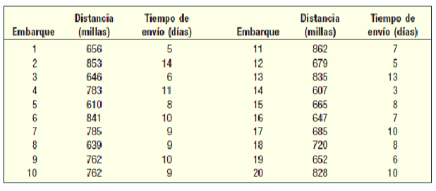

Considerando a la distancia de envío como la variable independiente y al tiempo de envío como la variable dependiente, haga lo siguiente:

# A. Preparacion de Datos - Diagrama de dispersion

Traslade la información de la tabla mostrada a un documento de texto, asígnele el nombre ‘entregas.txt’ y elabore un diagrama de dispersión para las variables numéricas.

### Lectura de datos

```r
#Leemos el archivo redactado

data = read.table("entrega.txt" , sep="", header=T)
data = data[-1]
data
```

```
##    distancia.millas T.envio.dias
## 1               656            5
## 2               853           14
## 3               646            6
## 4               783           11
## 5               610            8
## 6               841           10
## 7               785            9
## 8               639            9
## 9               762           10
## 10              762            9
## 11              862            7
## 12              679            5
## 13              835           13
## 14              607            3
## 15              665            8
## 16              647            7
## 17              685           10
## 18              720            8
## 19              652            6
## 20              828           10
```

[output not shown]

### Diagrama de dispersion

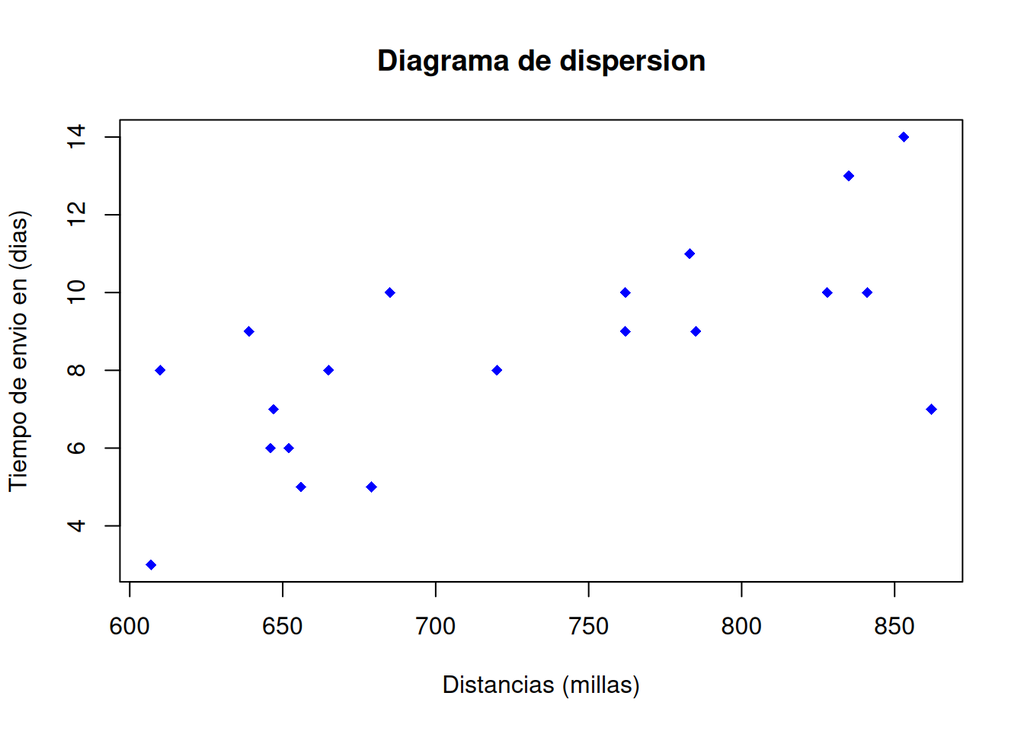

```r
x = data$distancia.millas
y = data$T.envio.dias

plot(x=x, y=y,
     pch=18, col="blue",
     xlab="Distancias (millas)",
     ylab="Tiempo de envio en (dias)",
     main="Diagrama de dispersion")
```

# B.Regresion Lineal

Realice un análisis de regresión, escriba la ecuación y grafique la recta de regresión.

Creamos el modelo

```r
modelo = lm(y ~ x)

#summary(modelo)

modelo$coefficients
```

```
## (Intercept)           x
## -7.12639554  0.02139064
```

### Escribiendo la ecuación

Con los resultados obtenidos podemos escribir la ecuación obtenida.

La ecuación de regresión lineal será:
$$\hat y = \hat\beta_0 + \hat\beta_1 x$$
y = -7.12639554 + 0.02139064x

### Graficamos la recta de regresion

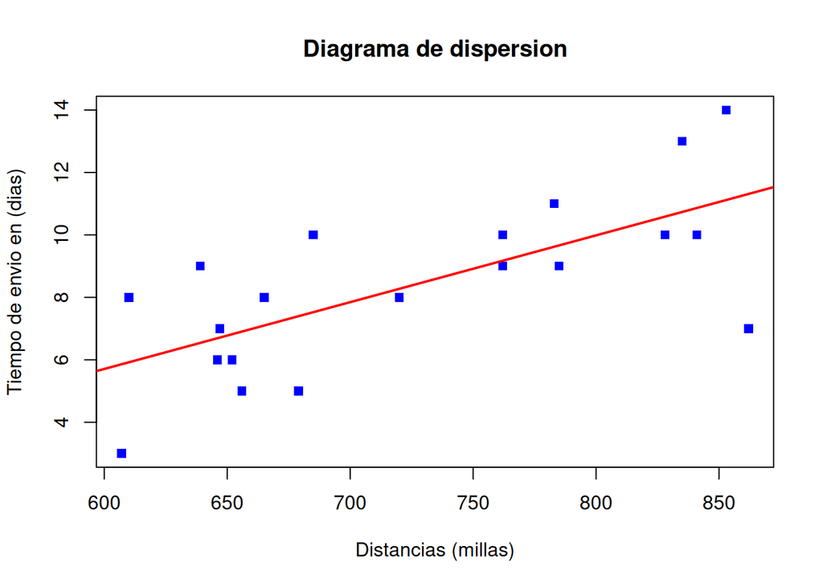

```r
plot(y ~ x ,
     pch=15, col="blue",
     xlab="Distancias (millas)", ylab="Tiempo de envio en (dias)", main="Diagrama de dispersion")

abline(modelo, col='red', lwd=2)
```

# C. Pronostico

Realice un pronóstico para distancias que van de 900 a 1000 millas en intervalos de 10.

```r
distancias_futuras = data.frame(x=seq(900, 1000, 10))

# Hacer las predicciones
dias_est = predict(object = modelo, newdata = distancias_futuras)

# Combinar distancias y predicciones en un solo data frame
resultados = data.frame(Distancia = distancias_futuras$x,
                        Dias_estimados = dias_est)

# Mostrar el data frame


# utilizamos la siguiente libreria, para una mejor visualizacion
library(knitr)
kable(resultados, digits = 5)
```

| Distancia | Dias_estimados |
| --- | --- |
| 900 | 12.12518 |
| 910 | 12.33909 |
| 920 | 12.55299 |
| 930 | 12.76690 |
| 940 | 12.98081 |
| 950 | 13.19471 |
| 960 | 13.40862 |
| 970 | 13.62252 |
| 980 | 13.83643 |
| 990 | 14.05034 |
| 1000 | 14.26424 |

## Interpretacion

- La ecuación que obtuvimos nos indica que por cada milla adicional recorrida, el valor de la variable dependiente aumenta en 0.02139064 unidades. Partiendo de un valor base negativo de -7.12639554, esto permite predecir valores que oscilan entre 12.12 y 14.26 para distancias de 900 a 1000 millas.